# LAPD_bias_investigation

Lael Hebert

May 1, 2019

# Problem

The purpose of this project is to identify areas of potential bias within vehicle and pedestrian stops made by the Los Angeles Police Department. The results of this study could be used to target areas within the LAPD that could benefit from anti-bias training. The goal is to reduce bias and improve relations and trust between police and community.

# Client

There are two main audiences of this analysis: the Los Angeles Police Department and citizen groups interested in police-community relations.

# Data

1. Vehicle and Pedestrian Stop Data 2010 to Present
   - This is the primary data set for this analysis. It contains records on over 7 million traffic stops. It includes information such as gender and ethnicity of the person stopped as well as information on the officer(s) involved in the stop.
   - Source: csv file from [data.gov](https://catalog.data.gov/dataset/lapd-vehicle-and-pedestrian-stops-2010-present)
   - Additional documentation of data fields at the [City of Los Angeles website](https://data.lacity.org/A-Safe-City/Vehicle-and-Pedestrian-Stop-Data-2010-to-Present/ci25-wgt7)
2. LAPD Reporting districts
   - A list of the reporting districts within Los Angeles and the precinct (division) and bureau associated with each
   - Source: csv file from [City of Los Angeles website](http://geohub.lacity.org/datasets/4398360b1a0242b78904f46b3786ae73_0)
3. Census_Data_by_Neighborhood_Council
   - This data set contains population counts by ethnicity for Los Angeles neighborhood based on the 2010 census.
   - Source: csv file from [data.gov](https://catalog.data.gov/dataset/census-data-by-neighborhood-council)
   - Additional documentation of data fields at the [City of Los Angeles website](https://data.lacity.org/A-Livable-and-Sustainable-City/Census-Data-by-Neighborhood-Council/nwj3-ufba)
4. Map of LAPD divisions from the Los Angeles times
   - This is an interactive map on the [LA Times website](http://maps.latimes.com/lapd/)
   - Clicking on a division leads to information on which neighborhoods the division patrols
5. Map of Los Angeles neighborhood councils
   - This is an interactive map of the [Los Angeles neighborhood councils](https://empowerla.org/city-map/)
6. [Census.gov](https://www.census.gov/quickfacts/fact/table/losangelescitycalifornia,losangelescountycalifornia/POP010210)
   - Used for verifying populations ethnicity distributions

## Data Cleaning

### Load packages and data

Start by loading packages. Then load all the data into R with good column types. Fix column names.

```r
library(dplyr)
library(readr)
library(lubridate)
```

```r
library(stringr)
library(tidyr)
library(ggplot2)

census_data <- read_csv("Census_Data_by_Neighborhood_Council.csv",
    col_types = cols(Hispanic_pop = col_double(),
        Owner_occ = col_skip(), Renter_occ = col_skip()))
census_data <- rename(census_data, neighborhood = NC_Name, Total_pop = "Total Population")

reporting_districts <- read_csv("LAPD_Reporting_Districts.csv",
    col_types = cols(AREA = col_skip(), OBJECTID = col_skip(),
        PERIMETER = col_skip(), PREC = col_character(),
        REPDIST = col_character(), Shape__Area = col_skip(),
        Shape__Length = col_skip()))
reporting_districts <- rename(reporting_districts, reporting_district = REPDIST, division_number = PREC, division = APREC, bureau = BUREAU, basic_car = BASICCAR)

stops_data <- read_csv("Vehicle_and_Pedestrian_Stop_Data_2010_to_Present.csv",
    col_types = cols(`Form Reference Number` = col_character(),
        `Officer 1 Serial Number` = col_character(),
        `Reporting District` = col_character(),
        `Stop Date` = col_date(format = "%m/%d/%Y"),
        `Stop Number` = col_character(),
        `Stop Time` = col_time(format = "%H:%M")))
names(stops_data) = c("stop_number", "form_reference_number", "gender_code", "ethnicity_code", "ethnicity", "date", "time", "officer_1_serial", "officer_1_division_num", "division_1", "officer_2_serial", "Officer_2_division_num", "division_2", "reporting_district", "stop_type", "post_stop_activity")

division_populations_all <- read_csv("Division_populations.csv")
division_pop <- read_csv("Division_populations.csv",
    col_types = cols(Asian_pop = col_skip(),
        Black_pop = col_skip(), Hispanic_pop = col_skip(),
        Other_pop = col_skip(), White_pop = col_skip(),
        total_pop = col_skip()))
division_pop <- rename(division_pop, WHITE = white_percent, BLACK = black_percent, ASIAN = asian_percent, HISPANIC = hispanic_percent, OTHER = other_percent)
```

### Clean up the stops data

Add a year column. If the reporting district starts with 0, remove the 0. Join the stops data with the reporting districts data to get the division and bureau where the stop took place. Rename the new columns in the stops data.

```r
stops_data <- stops_data %>%
  mutate(year = year(date)) %>%
  mutate(reporting_district = ifelse(grepl(pattern = "^0", reporting_district),
                                 str_sub(reporting_district, start = 2), reporting_district)) %>%
  left_join(reporting_districts, "reporting_district") %>%
  rename(stop_division_number = division_number, stop_division = division, stop_bureau = bureau, stop_basic_car = basic_car)
```

### Clean up the population data

The population data is missing from the hispanic column in the census data. Fill it in by subtracting the popultions of the other ethnicities from the total population. Calculate the total population of the city. Then created a vector of the percentages of each ethnicity city-wide.

```r
census_data$Hispanic_pop <- census_data$Total_pop -
  census_data$White_pop -
  census_data$Black_pop -
  census_data$Ameri_es_pop -
  census_data$Asian_pop -
  census_data$Hawn_pi_pop -
  census_data$Other_pop -
  census_data$Multi_pop

city_pop_total <- sum(census_data$Total_pop)
city_wide_percentages <- census_data[,3:10] %>%
  summarise_each(funs(sum))/city_pop_total
city_pop_total
```

```
## [1] 3736955
```

```r
city_wide_percentages
```

| White_pop | Black_pop | Ameri_es_pop | Asian_pop | Hawn_pi_pop | Hispanic_pop | Other_pop | Multi_pop |
| --- | --- | --- | --- | --- | --- | --- | --- |
| 0.2786887 | 0.09032228 | 0.001656504 | 0.1136676 | 0.001665522 | 0.4917433 | 0.002771385 | 0.01948472 |

According to the [Census.gov website](https://www.census.gov/quickfacts/fact/table/losangelescitycalifornia,losangelescountycalifornia/POP010210), Los Angeles had a population of 3.79 million people in 2010. This is very close to the 3.73 million reported in our census data set from the neighborhood council. The percentages by each ethnicity also match well. It looks like our calculation for the hispanic population will work.

### Complete stops data

Now, let’s combine all ethnicities that represent less than 2% of the population as “other.” We’ll change the ethnicity column in stops_data but leave the ethnicity_code column alone in case we need the original values later. Then write the results to a csv.

```r
unique(stops_data$ethnicity)
```

```
## [1] "BLACK"           "WHITE"           "ASIAN"           "OTHER"
## [5] "HISPANIC"        "AMERICAN INDIAN" "MULTI-DESCENTS"
```

```r
stops_data <- stops_data %>%
  mutate(ethnicity = ifelse(ethnicity %in% c("OTHER", "AMERICAN INDIAN", "MULTI-DESCENTS"), "OTHER", ethnicity))
unique(stops_data$ethnicity)
```

```
## [1] "BLACK"    "WHITE"    "ASIAN"    "OTHER"    "HISPANIC"
```

## Create data sets

### Ethnicity by division

Create some data sets: one with stop percentage by ethnicity for each division for all years. The second will have the same data broken out by year. For each data set, add data with the ethnicity data by division populations for the neighborhood.

```r
stops_summary_all_years <- stops_data %>%
  filter(!is.na(stop_division)) %>%
  group_by(stop_division, ethnicity) %>%
  summarise(ethnicity_count = n()) %>%
  mutate(ethnicity_percent = ethnicity_count/sum(ethnicity_count)) %>%
  mutate(location = "stops") %>%
  rename(division = stop_division)

stops_summary_ethnicity_totals_all_years <- stops_data %>%
  filter(!is.na(stop_division)) %>%
  group_by(ethnicity) %>%
  summarise(ethnicity_count = n()) %>%
  mutate(ethnicity_percent = ethnicity_count/sum(ethnicity_count)) %>%
  mutate(location = "stops") %>%
  mutate(division = "CITY TOTAL")

stops_summary_ethnicity_totals_all_years <- stops_summary_ethnicity_totals_all_years[c(5,1,2,3,4)]
stops_summary_all_years <- bind_rows(stops_summary_all_years, stops_summary_ethnicity_totals_all_years)

stops_summary_by_year <- stops_data %>%
  filter(!is.na(stop_division)) %>%
  group_by(stop_division, year, ethnicity) %>%
  summarise(ethnicity_count = n()) %>%
  mutate(ethnicity_percent = ethnicity_count/sum(ethnicity_count)) %>%
  mutate(location = "stops") %>%
  rename(division = stop_division)

stops_summary_ethnicity_totals_by_year <- stops_data %>%
  filter(!is.na(stop_division), year != 1900) %>%
  group_by(year, ethnicity) %>%
  summarise(ethnicity_count = n()) %>%
  mutate(ethnicity_percent = ethnicity_count/sum(ethnicity_count)) %>%
  mutate(location = "stops") %>%
  mutate(division = "CITY TOTAL")

stops_summary_ethnicity_totals_by_year <- stops_summary_ethnicity_totals_by_year[c(6,1,2,3,4,5)]
stops_summary_by_year <- bind_rows(stops_summary_by_year, stops_summary_ethnicity_totals_by_year)

#division_populations_all so that it is in the same form as stops_summary. Call it division_pop_gathered
division_counts <- division_populations_all[1:7] %>%
  rename(WHITE = White_pop, BLACK = Black_pop, ASIAN = Asian_pop, HISPANIC = Hispanic_pop, OTHER = Other_pop) %>%
  gather("ethnicity", "ethnicity_count", 2:7)
division_percents <- division_populations_all %>%
  select(1,8:12) %>%
  rename(WHITE = white_percent, BLACK = black_percent, ASIAN = asian_percent, HISPANIC = hispanic_percent, OTHER = other_percent)  %>%
  gather("ethnicity", "ethnicity_percent", 2:6)

division_pop_gathered <- left_join(division_counts,division_percents) %>%
  mutate(location = "population")
stops_summary_all_years_with_pop <- bind_rows(stops_summary_all_years, division_pop_gathered)
stops_summary_by_year_with_pop <- bind_rows(stops_summary_by_year, division_pop_gathered)
```

### Stop type

Create some data sets for stop type.

```r
#Get the percentage of each stop type broken down by ethnicity
stop_type_by_ethnicity_citywide_all_years <- stops_data %>%
  filter(!is.na(stop_type)) %>%
  group_by(stop_type, ethnicity) %>%
  summarise(ethnicity_count = n()) %>%
  mutate(ethnicity_percent = ethnicity_count/sum(ethnicity_count)) %>%
  mutate(division = "CITY TOTAL")

#Add city-wide total
stop_type_by_ethnicity_citywide_all_years <-
  division_pop_gathered %>%
  filter(division == "CITY TOTAL", !is.na(ethnicity_percent)) %>%
  rename(stop_type = location) %>%
  bind_rows(stop_type_by_ethnicity_citywide_all_years)

stop_type_by_ethnicity_citywide_by_year <- stops_data %>%
  filter(!is.na(stop_type), year >= 2010) %>%
  group_by(year, stop_type, ethnicity) %>%
  summarise(ethnicity_count = n()) %>%
  mutate(ethnicity_percent = ethnicity_count/sum(ethnicity_count)) %>%
  mutate(division = "CITY TOTAL")


#Get the percentage of each ethnicity broken down by stop type
ethnicity_by_stop_type_citywide_all_years <- stops_data %>%
  filter(!is.na(stop_type)) %>%
  group_by(ethnicity, stop_type) %>%
  summarise(ethnicity_count = n()) %>%
  mutate(ethnicity_percent = ethnicity_count/sum(ethnicity_count)) #%>%
  #mutate(division = "CITY TOTAL")

ethnicity_by_stop_type_citywide_all_years <-
  bind_rows(ethnicity_by_stop_type_citywide_all_years,
            ethnicity_by_stop_type_citywide_all_years %>%
              group_by(stop_type) %>%
              summarize(ethnicity_count = sum(ethnicity_count)) %>%
              mutate(ethnicity_percent = ethnicity_count/sum(ethnicity_count)) %>%
              mutate(ethnicity = "ALL")
            )
#Get the percentage of each ethnicity broken down by stop type for each division and year
ethnicity_by_stop_type_divisions_by_year <- stops_data %>%
  filter(!is.na(stop_type), !is.na(stop_division), year >= 2010) %>%
  group_by(stop_division, year, ethnicity, stop_type) %>%
  summarise(ethnicity_count = n()) %>%
  mutate(ethnicity_percent = ethnicity_count/sum(ethnicity_count)) %>%
  rename(division = stop_division)

ethnicity_by_stop_type_divisions_by_year <-
  bind_rows(ethnicity_by_stop_type_divisions_by_year,
            stops_data %>%
              filter(!is.na(stop_type), !is.na(stop_division)) %>%
              group_by(stop_division, year, stop_type) %>%
              summarise(ethnicity_count = n()) %>%
              mutate(ethnicity_percent = ethnicity_count/sum(ethnicity_count)) %>%
              mutate(ethnicity = "ALL") %>%
              rename(division = stop_division)
            )

#Get a table of vehicular stop percentage by year for each division:
division_vehicular_stop_percentage_by_year <-
  ethnicity_by_stop_type_divisions_by_year %>%
  group_by(division, year, stop_type) %>%
  summarise(ethnicity_count = sum(ethnicity_count)) %>%
  mutate(ethnicity_percent = ethnicity_count/sum(ethnicity_count)) %>%
  filter(stop_type == "VEH") %>%
  rename(vehicular_stop_percent = ethnicity_percent) %>%
  filter(!is.na(year))

division_vehicular_stop_percentage_all_years <-
  ethnicity_by_stop_type_divisions_by_year %>%
  group_by(year, stop_type) %>%
  summarise(ethnicity_count = sum(ethnicity_count)) %>%
  mutate(ethnicity_percent = ethnicity_count/sum(ethnicity_count)) %>%
  filter(stop_type == "VEH") %>%
  rename(vehicular_stop_percent = ethnicity_percent) %>%
  filter(!is.na(year)) %>%
  mutate(division = "CITY TOTAL")

division_vehicular_stop_percentage_by_year <-
  bind_rows(division_vehicular_stop_percentage_by_year, division_vehicular_stop_percentage_all_years)

division_vehicular_stop_percentage_by_year$stop_type = NULL
division_vehicular_stop_percentage_by_year$ethnicity_count = NULL
```

### Officers

Create some officer-based data sets.

```r
officer_total_stops_by_year <- stops_data %>%
  filter(!is.na(stop_division), !is.na(year)) %>%
  group_by(stop_division, officer_1_serial, year) %>%
  summarise(stops_count = n()) %>%
  rename(division = stop_division)

officer_black_stops_by_division_and_year <- stops_data %>%
  filter(!is.na(stop_division), !is.na(officer_1_serial), !is.na(year), ethnicity =="BLACK") %>%
  group_by(stop_division, officer_1_serial, year) %>%
  summarise(black_stops = n()) %>%
  rename(division = stop_division) %>%
  left_join(officer_total_stops_by_year) %>%
  rename(total_stops = stops_count) %>%
  mutate(officer_black_stop_percent = black_stops/total_stops) %>%
  left_join(select(division_pop, division, BLACK)) %>%
  rename(division_black__population_percent = BLACK) %>%
  left_join(select(filter(stops_summary_by_year, ethnicity == "BLACK", location == "stops"), division, ethnicity_percent)) %>%
  rename(division_black_stop_percent = ethnicity_percent)
```

### Division summary

Create a data set for a summary of each division.

```r
division_stop_ethnicities <-  filter(stops_summary_by_year, location == "stops", year >= 2010)
division_stop_ethnicities$location = NULL

division_stop_ethnicity_counts <- division_stop_ethnicities %>%
  select(1,2,3,4) %>%
  spread(key = ethnicity, value = ethnicity_count) %>%
  rename(asian_stop_count = ASIAN, black_stop_count = BLACK, hispanic_stop_count = HISPANIC, other_stop_count = OTHER, white_stop_count = WHITE)
division_stop_ethnicity_percents <- division_stop_ethnicities %>%
  select(1,2,3,5) %>%
  spread(key = ethnicity, value = ethnicity_percent) %>%
  rename(asian_stop_percent = ASIAN, black_stop_percent = BLACK, hispanic_stop_percent = HISPANIC, other_stop_percent = OTHER, white_stop_percent = WHITE)

division_by_year_summary <-
  left_join(division_stop_ethnicity_counts, division_stop_ethnicity_percents) %>%
  left_join(division_populations_all) %>%
  rename(asian_pop_percent = asian_percent, black_pop_percent = black_percent, hispanic_pop_percent = hispanic_percent,
         other_pop_percent = other_percent, white_pop_percent = white_percent) %>%
  mutate(total_stop_count = asian_stop_count + black_stop_count + hispanic_stop_count + other_stop_count + white_stop_count) %>%
  mutate(stop_to_pop_ratio = total_stop_count / total_pop) %>%
  left_join(division_vehicular_stop_percentage_by_year)
write_csv(division_by_year_summary, path = "C:/Users/lahebert.REDMOND/Documents/Learning/Springboard/Introduction to Data Science/Capstone/Data/Output/division_by_year_summary.csv")
```

## City-wide graphs

### City-wide ethnicity breakdown

Start by graphing ethnicity percentages by populations and stops city-wide

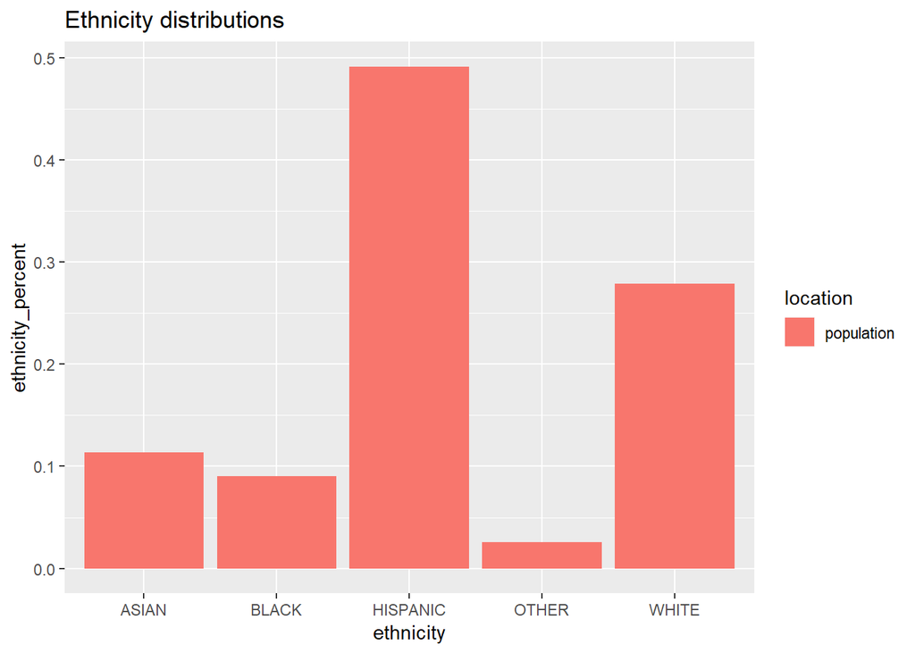

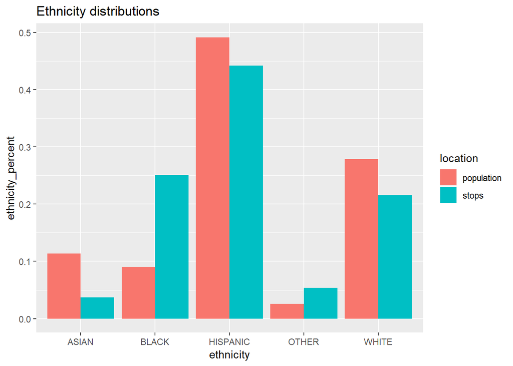

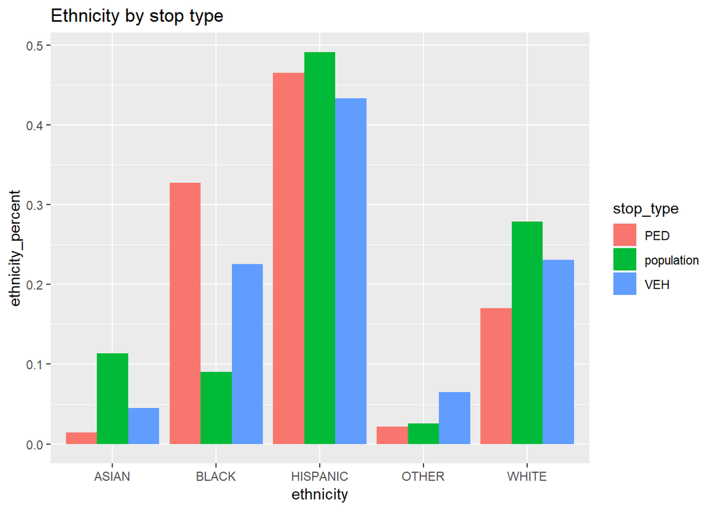

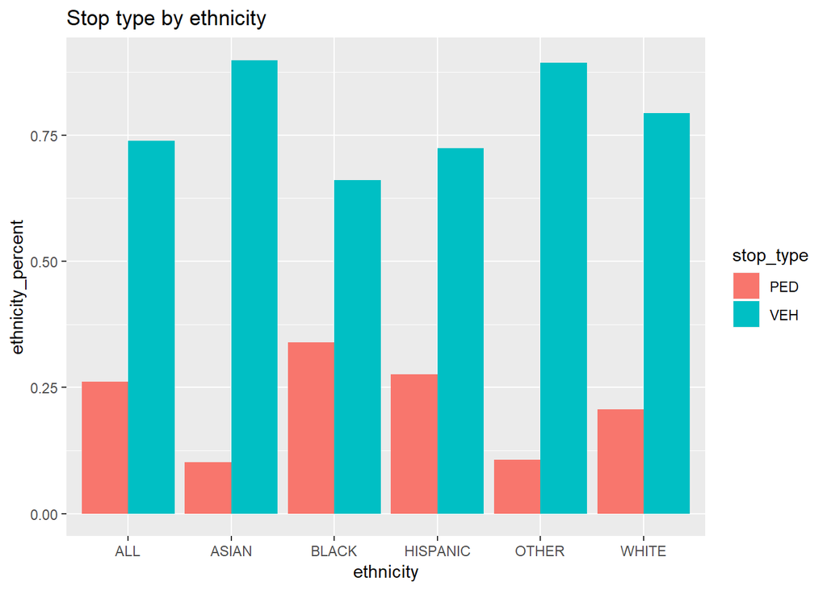

### Trend in black stops

Let’s graph the percentage of stops that are for the black population by year, with a regression line. Then we’ll add the regression parameters.

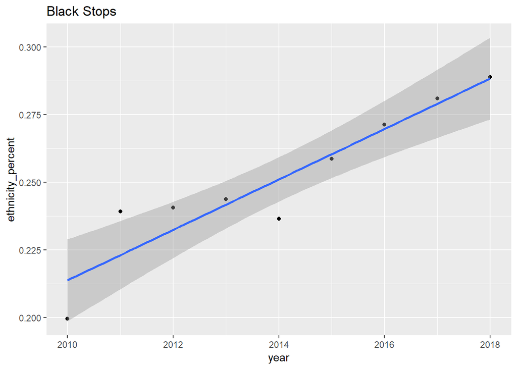

```
##
## Call:
## lm(formula = ethnicity_percent ~ year, data = filter(stops_summary_by_year_with_pop,
##     division == "CITY TOTAL", ethnicity == "BLACK", location ==
##         "stops"))
##
## Residuals:
##       Min        1Q    Median        3Q       Max
## -0.017928 -0.009218  0.004356  0.007771  0.013809
##
## Coefficients:
##               Estimate Std. Error t value Pr(>|t|)
## (Intercept) -15.750160   2.687029  -5.862 0.000378 ***
## year          0.007944   0.001334   5.956 0.000340 ***
## ---
## Signif. codes:  0 '***' 0.001 '**' 0.01 '*' 0.05 '.' 0.1 ' ' 1
##
## Residual standard error: 0.01212 on 8 degrees of freedom
## Multiple R-squared:  0.816,  Adjusted R-squared:  0.793
## F-statistic: 35.47 on 1 and 8 DF,  p-value: 0.0003398
```

### Ethnicity breakdown by division

The percentage of stops of black people is increasing by about 0.8 percentage points a year. Let’s look at the ethnicity breakdowns for each of the divisions.

[figure not shown]

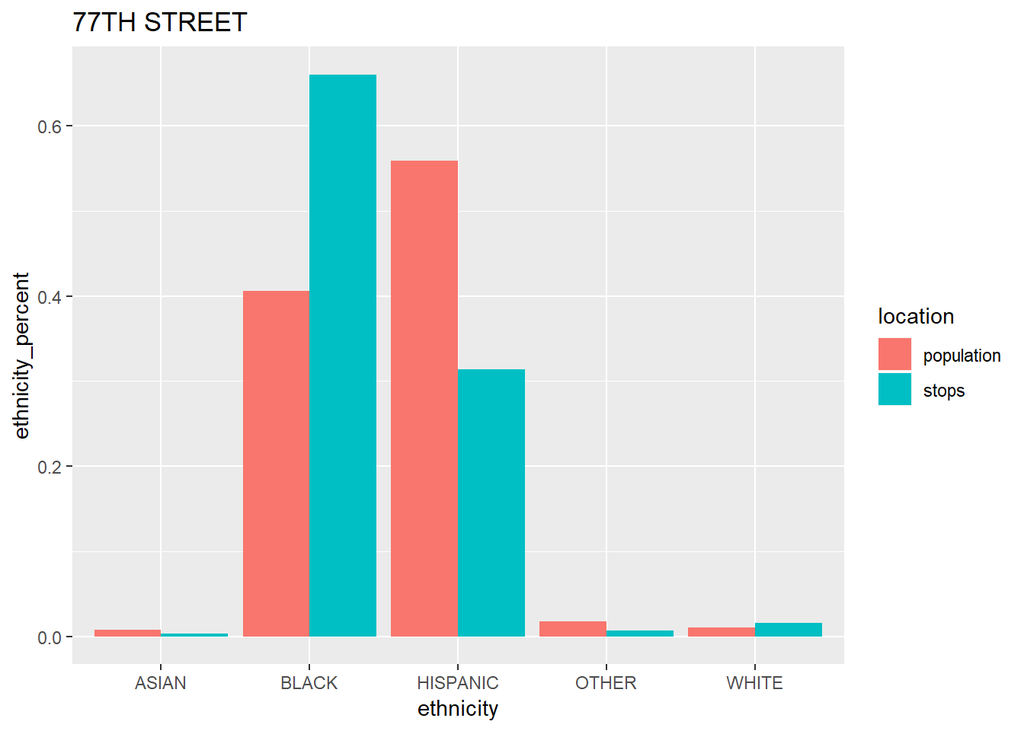

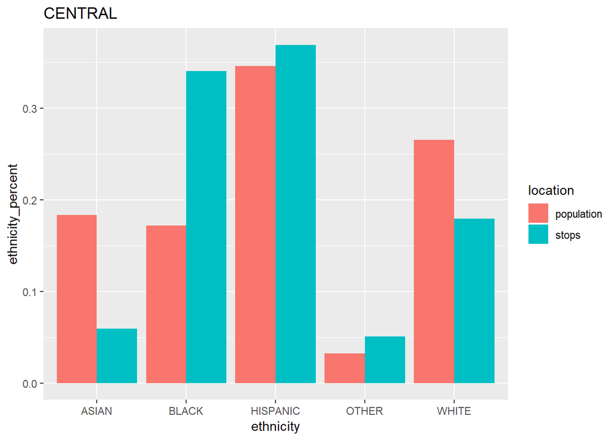

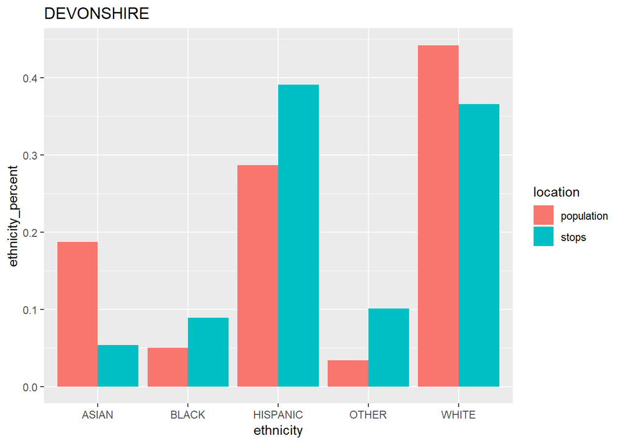

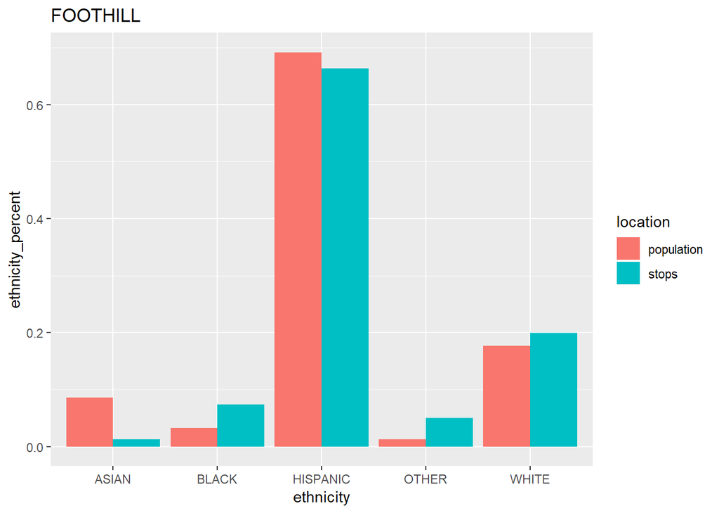

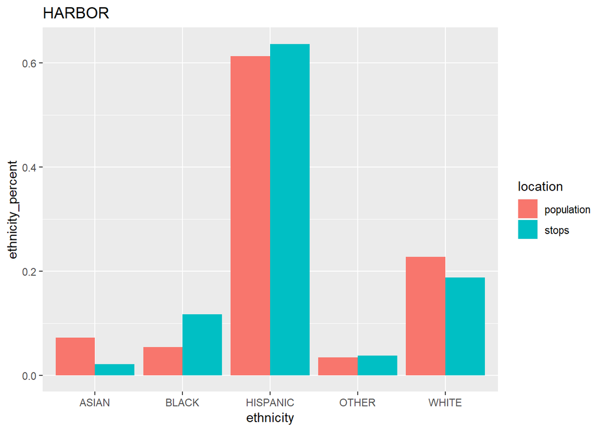

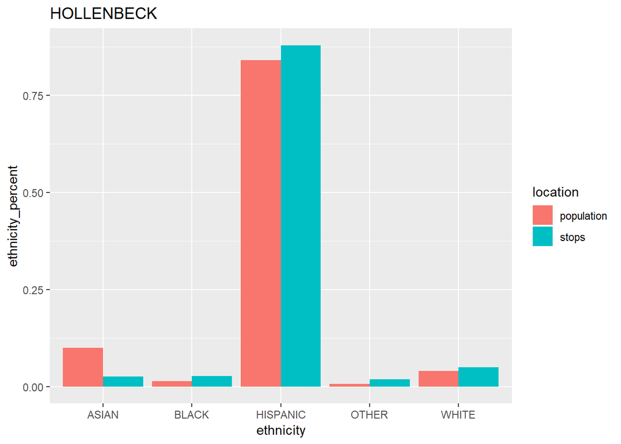

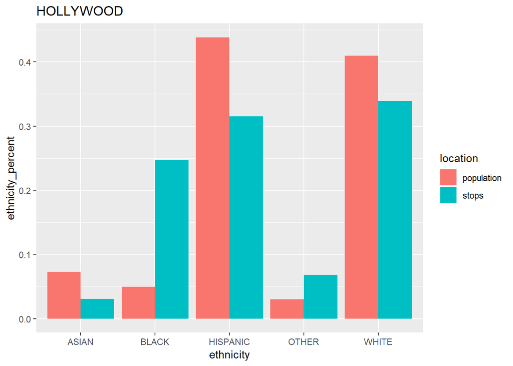

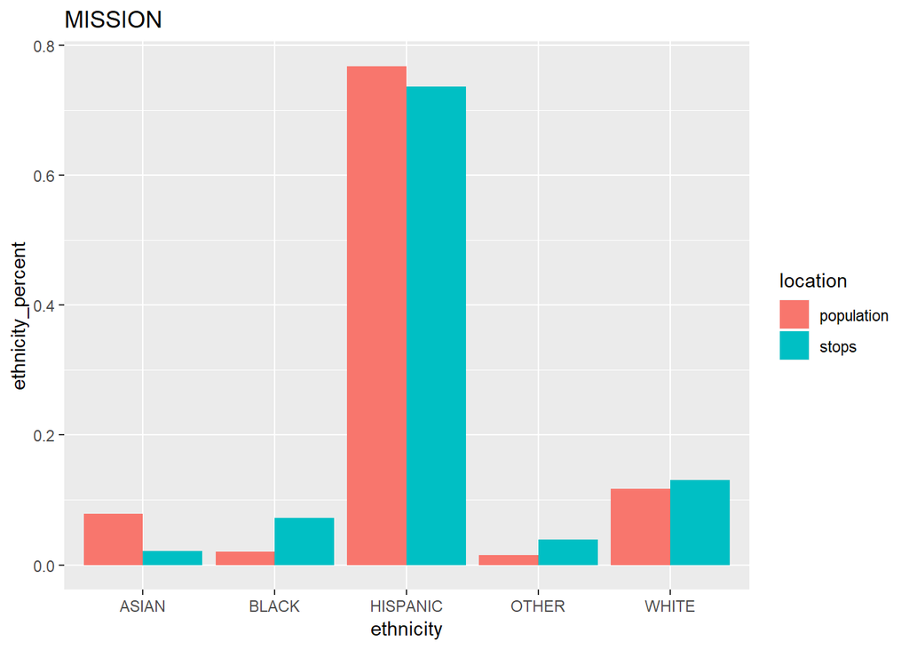

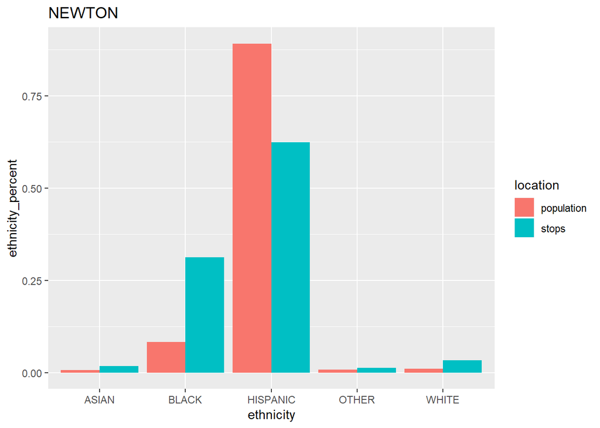

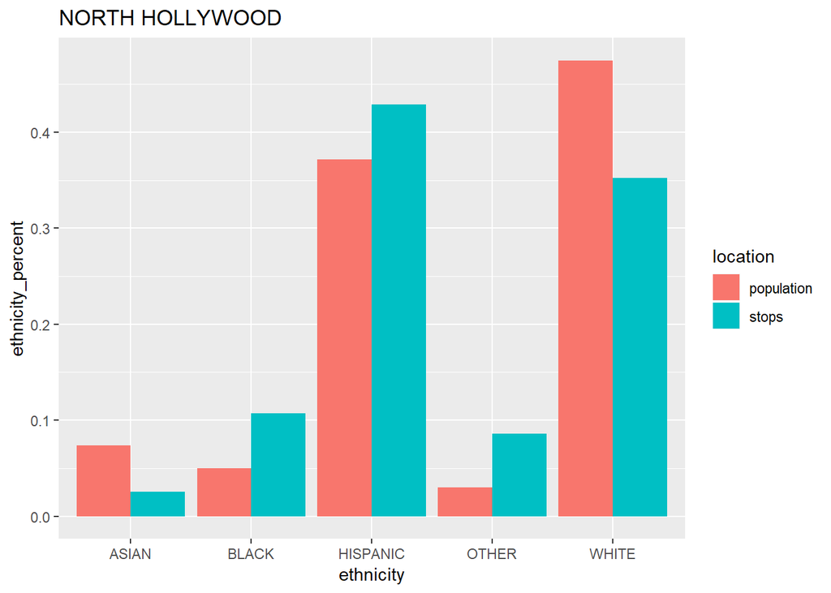

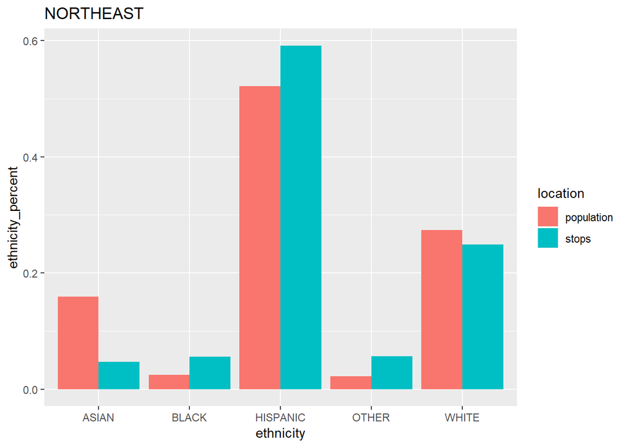

[11 more figures not shown]

### Black stops by division

Try some more graphs. Plot the black population verses the number of black stops for each division. Then plot the population percentage verses stops percentage by division for blacks.

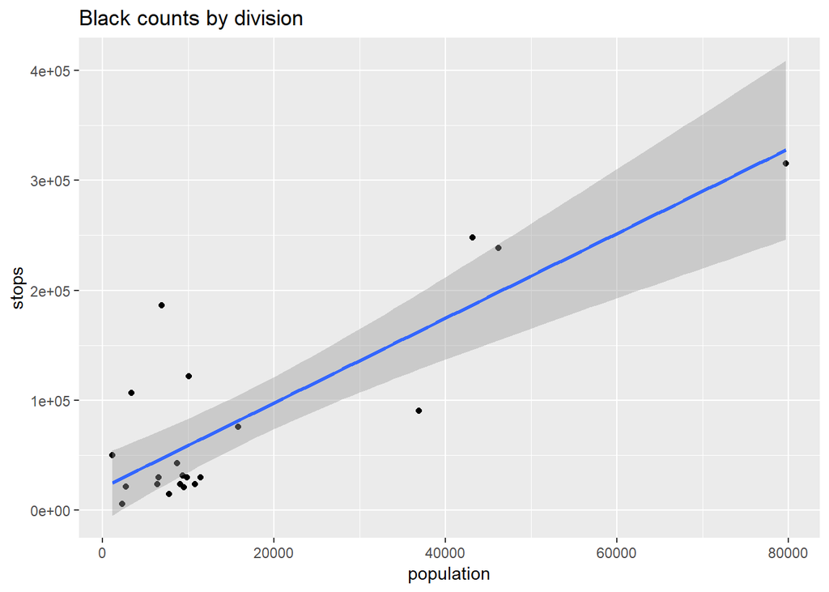

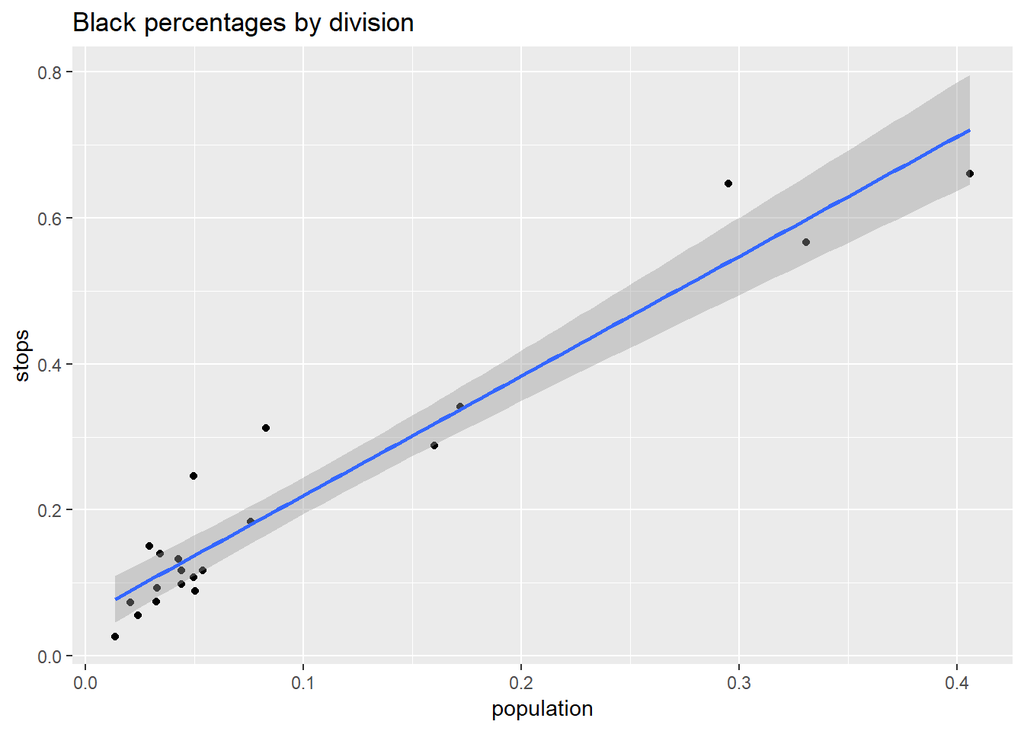

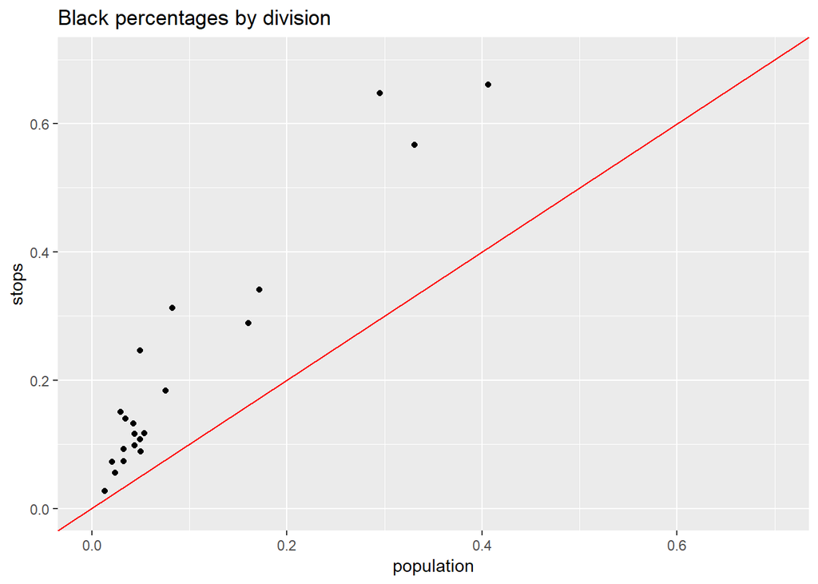

[figure not shown]

### All ethnicity stops by division

Let’s look at the percentages graph for all ethnicities

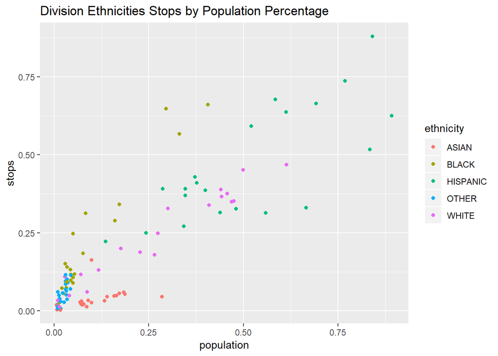

## Division Analysis graphs

### Graph division trends

Graph the trend in black stops for each division and output the summary for the linear regression line.

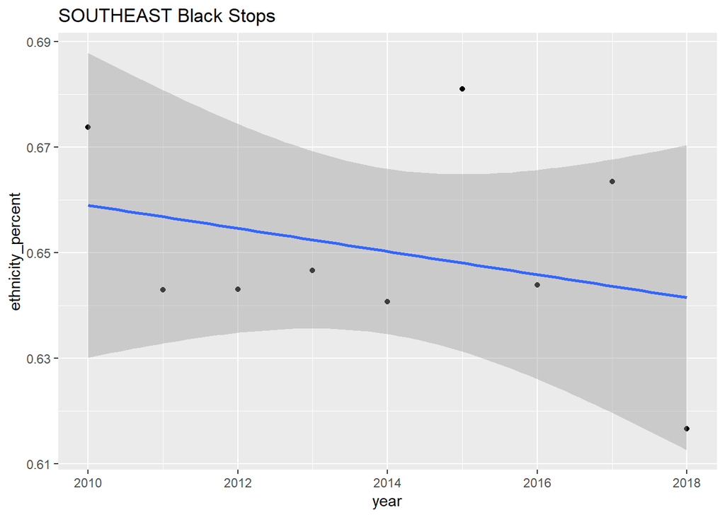

```
##
## Call:
## lm(formula = ethnicity_percent ~ year, data = filter(stops_summary_by_year_with_pop,
##     division == div, ethnicity == "BLACK", location == "stops"))
##
## Residuals:
##       Min        1Q    Median        3Q       Max
## -0.034083 -0.012511 -0.005261  0.007416  0.039536
##
## Coefficients:
##              Estimate Std. Error t value Pr(>|t|)
## (Intercept) 10.775664   5.281794   2.040   0.0757 .
## year        -0.005029   0.002622  -1.918   0.0914 .
## ---
## Signif. codes:  0 '***' 0.001 '**' 0.01 '*' 0.05 '.' 0.1 ' ' 1
##
## Residual standard error: 0.02381 on 8 degrees of freedom
## Multiple R-squared:  0.315,  Adjusted R-squared:  0.2294
## F-statistic:  3.68 on 1 and 8 DF,  p-value: 0.09136
```

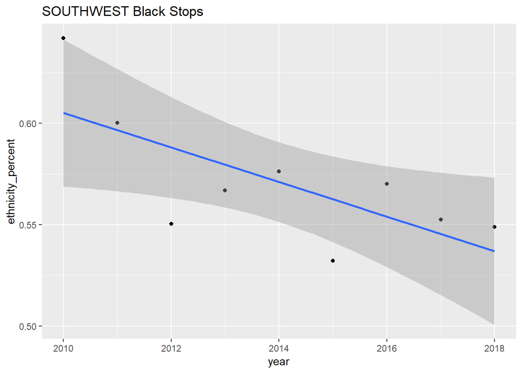

```
##
## Call:
## lm(formula = ethnicity_percent ~ year, data = filter(stops_summary_by_year_with_pop,
##     division == div, ethnicity == "BLACK", location == "stops"))
##
## Residuals:
##       Min        1Q    Median        3Q       Max
## -0.036624 -0.010054  0.002695  0.009407  0.041599
##
## Coefficients:
##              Estimate Std. Error t value Pr(>|t|)
## (Intercept) 14.237542   5.570828   2.556   0.0339 *
## year        -0.006785   0.002765  -2.453   0.0397 *
## ---
## Signif. codes:  0 '***' 0.001 '**' 0.01 '*' 0.05 '.' 0.1 ' ' 1
##
## Residual standard error: 0.02512 on 8 degrees of freedom
## Multiple R-squared:  0.4294, Adjusted R-squared:  0.358
## F-statistic: 6.019 on 1 and 8 DF,  p-value: 0.03972
```

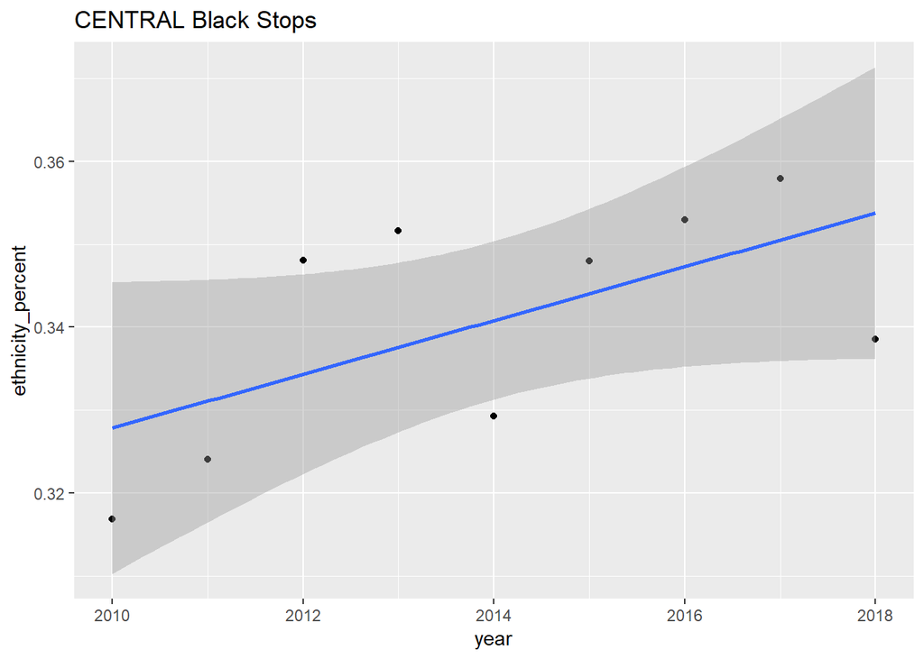

```
##
## Call:
## lm(formula = ethnicity_percent ~ year, data = filter(stops_summary_by_year_with_pop,
##     division == div, ethnicity == "BLACK", location == "stops"))
##
## Residuals:
##        Min         1Q     Median         3Q        Max
## -0.0178999 -0.0095686  0.0000571  0.0122184  0.0145748
##
## Coefficients:
##              Estimate Std. Error t value Pr(>|t|)
## (Intercept) -3.181249   3.051031  -1.043    0.328
## year         0.001748   0.001515   1.154    0.282
##
## Residual standard error: 0.01376 on 8 degrees of freedom
## Multiple R-squared:  0.1427, Adjusted R-squared:  0.03555
## F-statistic: 1.332 on 1 and 8 DF,  p-value: 0.2818
```

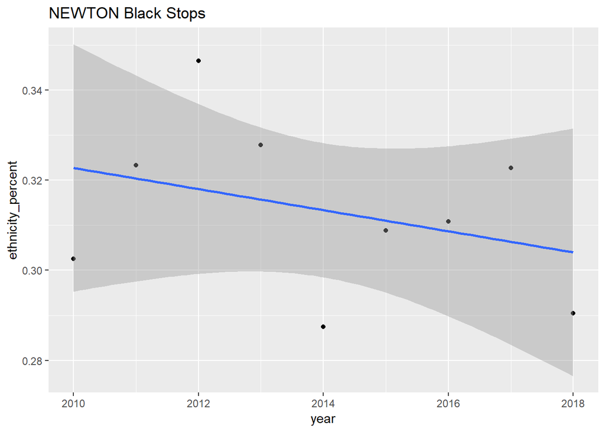

```
##
## Call:
## lm(formula = ethnicity_percent ~ year, data = filter(stops_summary_by_year_with_pop,
##     division == div, ethnicity == "BLACK", location == "stops"))
##
## Residuals:
##        Min         1Q     Median         3Q        Max
## -0.0246465 -0.0161927  0.0009135  0.0113804  0.0273171
##
## Coefficients:
##              Estimate Std. Error t value Pr(>|t|)
## (Intercept)  8.395413   4.378303   1.918   0.0915 .
## year        -0.004014   0.002173  -1.847   0.1020
## ---
## Signif. codes:  0 '***' 0.001 '**' 0.01 '*' 0.05 '.' 0.1 ' ' 1
##
## Residual standard error: 0.01974 on 8 degrees of freedom
## Multiple R-squared:  0.2989, Adjusted R-squared:  0.2113
## F-statistic: 3.411 on 1 and 8 DF,  p-value: 0.102
```

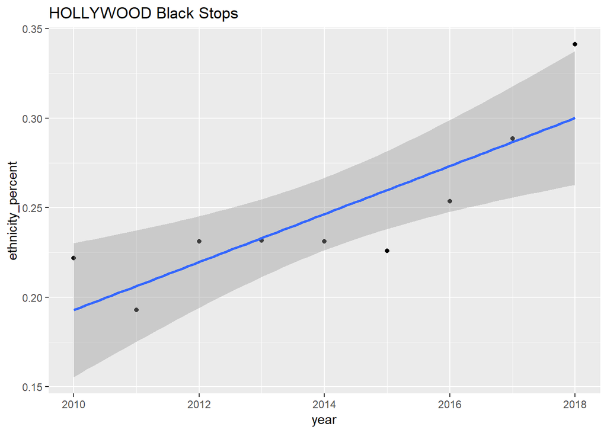

```
##
## Call:
## lm(formula = ethnicity_percent ~ year, data = filter(stops_summary_by_year_with_pop,
##     division == div, ethnicity == "BLACK", location == "stops"))
##
## Residuals:
##       Min        1Q    Median        3Q       Max
## -0.033987 -0.014784 -0.000475  0.009141  0.041042
##
## Coefficients:
##               Estimate Std. Error t value Pr(>|t|)
## (Intercept) -26.829471   5.333428  -5.030 0.001014 **
## year          0.013444   0.002648   5.078 0.000956 ***
## ---
## Signif. codes:  0 '***' 0.001 '**' 0.01 '*' 0.05 '.' 0.1 ' ' 1
##
## Residual standard error: 0.02405 on 8 degrees of freedom
## Multiple R-squared:  0.7632, Adjusted R-squared:  0.7336
## F-statistic: 25.79 on 1 and 8 DF,  p-value: 0.0009556
```

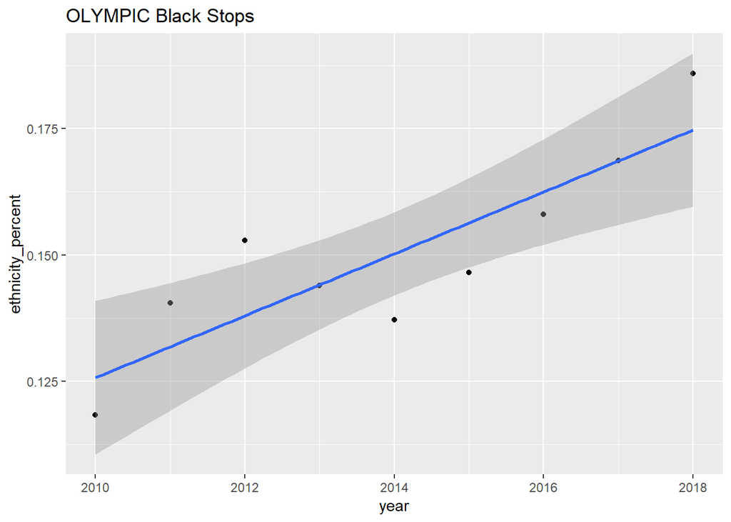

```
##
## Call:
## lm(formula = ethnicity_percent ~ year, data = filter(stops_summary_by_year_with_pop,
##     division == div, ethnicity == "BLACK", location == "stops"))
##
## Residuals:
##       Min        1Q    Median        3Q       Max
## -0.014338 -0.007008 -0.002264  0.009214  0.015577
##
## Coefficients:
##               Estimate Std. Error t value Pr(>|t|)
## (Intercept) -14.144934   2.445449  -5.784 0.000413 ***
## year          0.007099   0.001214   5.848 0.000384 ***
## ---
## Signif. codes:  0 '***' 0.001 '**' 0.01 '*' 0.05 '.' 0.1 ' ' 1
##
## Residual standard error: 0.01103 on 8 degrees of freedom
## Multiple R-squared:  0.8104, Adjusted R-squared:  0.7867
## F-statistic: 34.19 on 1 and 8 DF,  p-value: 0.0003838
```

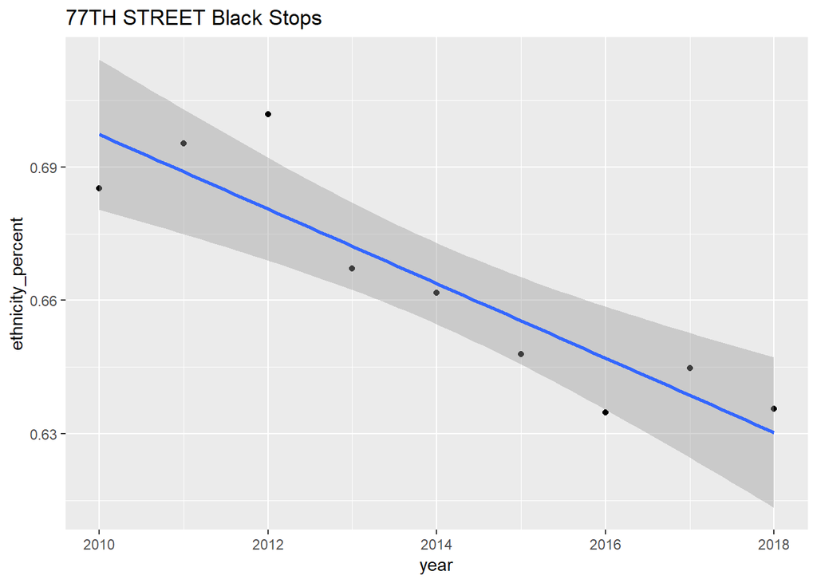

```
##
## Call:
## lm(formula = ethnicity_percent ~ year, data = filter(stops_summary_by_year_with_pop,
##     division == div, ethnicity == "BLACK", location == "stops"))
##
## Residuals:
##        Min         1Q     Median         3Q        Max
## -0.0148096 -0.0082714 -0.0009149  0.0064294  0.0217664
##
## Coefficients:
##              Estimate Std. Error t value Pr(>|t|)
## (Intercept) 16.018969   2.566201   6.242 0.000248 ***
## year        -0.007624   0.001274  -5.985 0.000329 ***
## ---
## Signif. codes:  0 '***' 0.001 '**' 0.01 '*' 0.05 '.' 0.1 ' ' 1
##
## Residual standard error: 0.01157 on 8 degrees of freedom
## Multiple R-squared:  0.8174, Adjusted R-squared:  0.7946
## F-statistic: 35.82 on 1 and 8 DF,  p-value: 0.000329
```

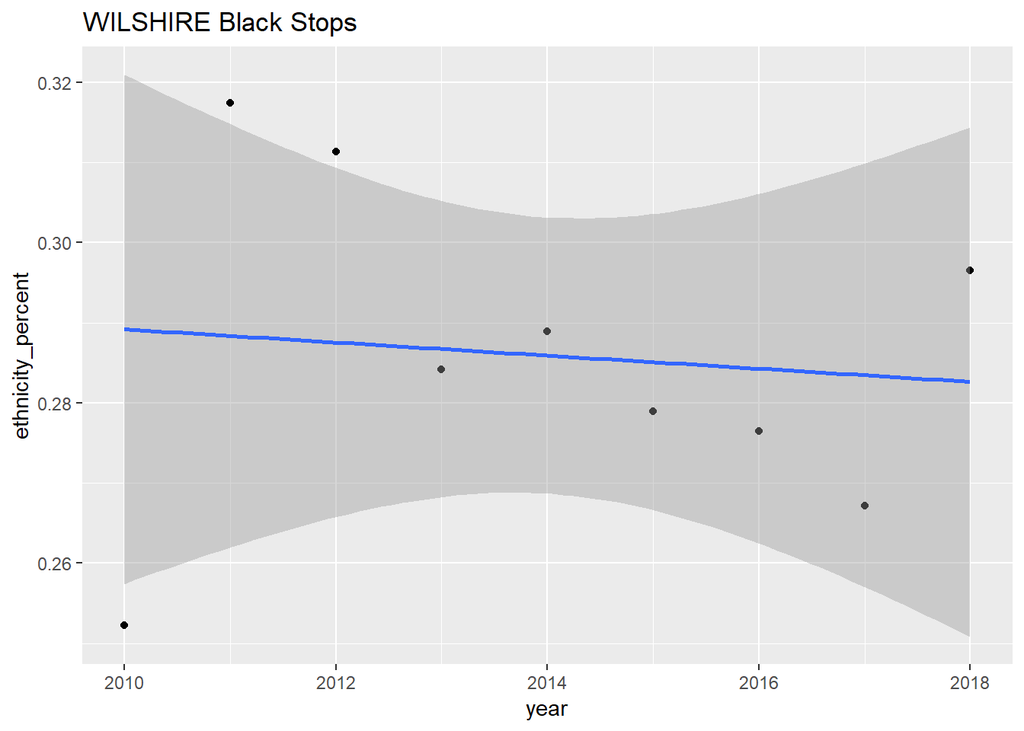

```
##
## Call:
## lm(formula = ethnicity_percent ~ year, data = filter(stops_summary_by_year_with_pop,
##     division == div, ethnicity == "BLACK", location == "stops"))
##
## Residuals:
##       Min        1Q    Median        3Q       Max
## -0.037546 -0.006678 -0.002649  0.012153  0.028659
##
## Coefficients:
##              Estimate Std. Error t value Pr(>|t|)
## (Intercept)  2.413736   4.543820   0.531    0.610
## year        -0.001057   0.002256  -0.468    0.652
##
## Residual standard error: 0.02049 on 8 degrees of freedom
##   (1 observation deleted due to missingness)
## Multiple R-squared:  0.0267, Adjusted R-squared:  -0.09496
## F-statistic: 0.2195 on 1 and 8 DF,  p-value: 0.6519
```

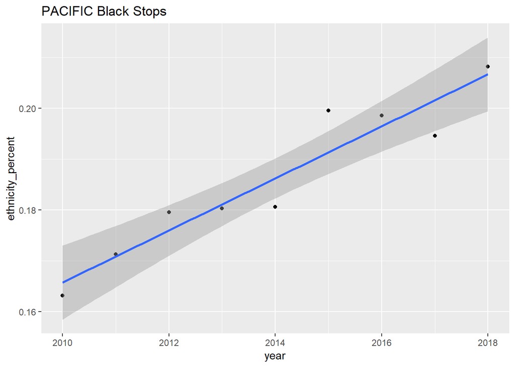

```
##
## Call:
## lm(formula = ethnicity_percent ~ year, data = filter(stops_summary_by_year_with_pop,
##     division == div, ethnicity == "BLACK", location == "stops"))
##
## Residuals:
##        Min         1Q     Median         3Q        Max
## -0.0087493 -0.0013148  0.0000458  0.0031850  0.0072831
##
## Coefficients:
##               Estimate Std. Error t value Pr(>|t|)
## (Intercept) -1.094e+01  1.140e+00  -9.598 1.15e-05 ***
## year         5.525e-03  5.658e-04   9.764 1.01e-05 ***
## ---
## Signif. codes:  0 '***' 0.001 '**' 0.01 '*' 0.05 '.' 0.1 ' ' 1
##
## Residual standard error: 0.005139 on 8 degrees of freedom
## Multiple R-squared:  0.9226, Adjusted R-squared:  0.9129
## F-statistic: 95.34 on 1 and 8 DF,  p-value: 1.014e-05
```